# Soccer Dataset Analysis

### Question posed : What are the attributes of a high ranking player ?

#### Data source and attributes

The data was downloaded from [Kaggle](https://www.kaggle.com/hugomathien/soccer). The tables present in the sqlite database are :

1. Country
2. League
3. Match
4. Player
5. Player_Attributes
6. Team
7. Team_Attributes

The above list was retrieved by typing `.tables` in sqlite prompt.

### Analysis Process

#### Import dependencies and connect to the database

```python
!pip3 install pandas
```

```python
import pandas as pd
import sqlite3
# Connect to the database named 'database.sqlite', located in the same directory
conn = sqlite3.connect('database.sqlite')
```

#### The list of players and their attributes.

```python
# Import the players table into a pandas dataframe
players = pd.read_sql('SELECT * FROM Player;', conn)
players
```

|  | id | player_api_id | player_name | player_fifa_api_id | birthday | height | weight |
| --- | --- | --- | --- | --- | --- | --- | --- |
| 0 | 1 | 505942 | Aaron Appindangoye | 218353 | 1992-02-29 00:00:00 | 182.88 | 187 |
| 1 | 2 | 155782 | Aaron Cresswell | 189615 | 1989-12-15 00:00:00 | 170.18 | 146 |
| 2 | 3 | 162549 | Aaron Doran | 186170 | 1991-05-13 00:00:00 | 170.18 | 163 |
| 3 | 4 | 30572 | Aaron Galindo | 140161 | 1982-05-08 00:00:00 | 182.88 | 198 |
| 4 | 5 | 23780 | Aaron Hughes | 17725 | 1979-11-08 00:00:00 | 182.88 | 154 |
| ... | ... | ... | ... | ... | ... | ... | ... |
| 11055 | 11071 | 26357 | Zoumana Camara | 2488 | 1979-04-03 00:00:00 | 182.88 | 168 |
| 11056 | 11072 | 111182 | Zsolt Laczko | 164680 | 1986-12-18 00:00:00 | 182.88 | 176 |
| 11057 | 11073 | 36491 | Zsolt Low | 111191 | 1979-04-29 00:00:00 | 180.34 | 154 |
| 11058 | 11074 | 35506 | Zurab Khizanishvili | 47058 | 1981-10-06 00:00:00 | 185.42 | 172 |
| 11059 | 11075 | 39902 | Zvjezdan Misimovic | 102359 | 1982-06-05 00:00:00 | 180.34 | 176 |

11060 rows × 7 columns

```python
# Import the player_attributes table into a dataframe
player_attributes = pd.read_sql('SELECT * FROM player_attributes;', conn)
```

```python
player_attributes.head()
player_attributes.query('player_api_id == 505942')
```

|  | id | player_fifa_api_id | player_api_id | date | overall_rating | potential | preferred_foot | attacking_work_rate | defensive_work_rate | crossing | ... | vision | penalties | marking | standing_tackle | sliding_tackle | gk_diving | gk_handling | gk_kicking | gk_positioning | gk_reflexes |
| --- | --- | --- | --- | --- | --- | --- | --- | --- | --- | --- | --- | --- | --- | --- | --- | --- | --- | --- | --- | --- | --- |
| 0 | 1 | 218353 | 505942 | 2016-02-18 00:00:00 | 67.0 | 71.0 | right | medium | medium | 49.0 | ... | 54.0 | 48.0 | 65.0 | 69.0 | 69.0 | 6.0 | 11.0 | 10.0 | 8.0 | 8.0 |
| 1 | 2 | 218353 | 505942 | 2015-11-19 00:00:00 | 67.0 | 71.0 | right | medium | medium | 49.0 | ... | 54.0 | 48.0 | 65.0 | 69.0 | 69.0 | 6.0 | 11.0 | 10.0 | 8.0 | 8.0 |
| 2 | 3 | 218353 | 505942 | 2015-09-21 00:00:00 | 62.0 | 66.0 | right | medium | medium | 49.0 | ... | 54.0 | 48.0 | 65.0 | 66.0 | 69.0 | 6.0 | 11.0 | 10.0 | 8.0 | 8.0 |
| 3 | 4 | 218353 | 505942 | 2015-03-20 00:00:00 | 61.0 | 65.0 | right | medium | medium | 48.0 | ... | 53.0 | 47.0 | 62.0 | 63.0 | 66.0 | 5.0 | 10.0 | 9.0 | 7.0 | 7.0 |
| 4 | 5 | 218353 | 505942 | 2007-02-22 00:00:00 | 61.0 | 65.0 | right | medium | medium | 48.0 | ... | 53.0 | 47.0 | 62.0 | 63.0 | 66.0 | 5.0 | 10.0 | 9.0 | 7.0 | 7.0 |

5 rows × 42 columns

#### The player attributes are gathered over multiple years ( 2007 - 2016 ), so for this analysis I've aggregated a player's ratings over the years.

```python
# take the mean of attributes for each player
aggregated_player_attributes = player_attributes.groupby('player_fifa_api_id').mean()
# drop the id and player_api_id columns
aggregated_player_attributes.drop(['id', 'player_api_id'], axis=1, inplace=True)
aggregated_player_attributes
```

| player_fifa_api_id | overall_rating | potential | crossing | finishing | heading_accuracy | short_passing | volleys | dribbling | curve | free_kick_accuracy | ... | vision | penalties | marking | standing_tackle | sliding_tackle | gk_diving | gk_handling | gk_kicking | gk_positioning | gk_reflexes |
| --- | --- | --- | --- | --- | --- | --- | --- | --- | --- | --- | --- | --- | --- | --- | --- | --- | --- | --- | --- | --- | --- |
| 2 | 70.600000 | 71.100000 | 74.100000 | 48.033333 | 62.800000 | 71.200000 | 56.566667 | 66.600000 | 67.733333 | 60.600 | ... | 55.766667 | 59.766667 | 71.466667 | 74.000000 | 72.833333 | 13.300000 | 7.633333 | 26.000000 | 11.766667 | 13.466667 |
| 6 | 72.125000 | 76.250000 | 18.000000 | 18.000000 | 24.000000 | 28.750000 | 6.500000 | 17.000000 | 7.250000 | 15.375 | ... | 42.000000 | 25.250000 | 24.750000 | 24.125000 | 17.000000 | 71.750000 | 72.375000 | 71.000000 | 75.250000 | 72.750000 |
| 11 | 67.352941 | 69.411765 | 63.588235 | 54.352941 | 60.882353 | 71.882353 | 64.470588 | 67.117647 | 69.058824 | 51.000 | ... | 68.882353 | 68.117647 | 45.117647 | 49.588235 | 58.941176 | 6.000000 | 7.058824 | 13.941176 | 7.470588 | 11.882353 |
| 16 | 74.125000 | 76.562500 | 74.187500 | 73.937500 | 64.000000 | 68.750000 | 72.625000 | 76.125000 | 77.562500 | 76.750 | ... | 59.875000 | 75.750000 | 27.062500 | 31.062500 | 21.000000 | 9.250000 | 13.625000 | 24.250000 | 12.937500 | 12.562500 |
| 27 | 76.500000 | 77.600000 | 80.933333 | 69.833333 | 49.833333 | 80.133333 | 76.833333 | 82.333333 | 83.333333 | 76.800 | ... | 81.366667 | 67.700000 | 37.133333 | 36.200000 | 29.333333 | 8.333333 | 7.666667 | 21.766667 | 16.033333 | 8.333333 |
| ... | ... | ... | ... | ... | ... | ... | ... | ... | ... | ... | ... | ... | ... | ... | ... | ... | ... | ... | ... | ... | ... |
| 233885 | 52.000000 | 67.666667 | 29.000000 | 18.000000 | 52.000000 | 31.000000 | 26.000000 | 25.000000 | 25.000000 | 27.000 | ... | 32.000000 | 35.000000 | 49.000000 | 56.000000 | 52.000000 | 6.000000 | 8.000000 | 5.000000 | 7.000000 | 6.000000 |
| 233911 | 58.000000 | 66.000000 | 51.000000 | 25.000000 | 41.000000 | 51.000000 | 22.000000 | 45.000000 | 33.000000 | 31.000 | ... | 33.000000 | 35.000000 | 56.000000 | 61.000000 | 65.000000 | 5.000000 | 8.000000 | 6.000000 | 9.000000 | 5.000000 |
| 233930 | 59.000000 | 66.000000 | 55.000000 | 28.000000 | 50.000000 | 35.000000 | 29.000000 | 67.000000 | 37.000000 | 39.000 | ... | 40.000000 | 43.000000 | 55.000000 | 69.000000 | 62.000000 | 7.000000 | 10.000000 | 7.000000 | 9.000000 | 9.000000 |
| 233969 | 58.000000 | 68.000000 | 48.000000 | 26.000000 | 57.000000 | 49.000000 | 24.000000 | 41.000000 | 39.000000 | 20.000 | ... | 36.000000 | 45.000000 | 63.000000 | 69.000000 | 68.000000 | 8.000000 | 8.000000 | 12.000000 | 12.000000 | 6.000000 |
| 234141 | 58.000000 | 66.000000 | 47.000000 | 39.000000 | 53.000000 | 60.000000 | 37.000000 | 54.000000 | 40.000000 | 45.000 | ... | 47.000000 | 52.000000 | 56.000000 | 66.000000 | 62.000000 | 8.000000 | 9.000000 | 13.000000 | 11.000000 | 13.000000 |

11062 rows × 35 columns

#### Merge the dataframes - player and aggregated_player_attributes, to get a unified dataframe of the players.

```python
players_data = players.merge(aggregated_player_attributes, on='player_fifa_api_id', how='left')
players_data.drop('id', axis=1, inplace=True)
players_data.describe()
```

|  | player_api_id | player_fifa_api_id | height | weight | overall_rating | potential | crossing | finishing | heading_accuracy | short_passing | ... | vision | penalties | marking | standing_tackle | sliding_tackle | gk_diving | gk_handling | gk_kicking | gk_positioning | gk_reflexes |
| --- | --- | --- | --- | --- | --- | --- | --- | --- | --- | --- | --- | --- | --- | --- | --- | --- | --- | --- | --- | --- | --- |
| count | 11060.000000 | 11060.000000 | 11060.000000 | 11060.000000 | 11060.000000 | 11060.000000 | 11060.000000 | 11060.000000 | 11060.000000 | 11060.000000 | ... | 10582.000000 | 11060.000000 | 11060.000000 | 11060.000000 | 10582.000000 | 11060.000000 | 11060.000000 | 11060.000000 | 11060.000000 | 11060.000000 |
| mean | 156582.427215 | 165664.910488 | 181.867445 | 168.380289 | 66.820293 | 72.089844 | 52.853322 | 47.860847 | 56.103099 | 60.367430 | ... | 55.867496 | 53.685878 | 46.237805 | 49.446600 | 47.131852 | 14.908181 | 16.674666 | 23.016234 | 16.748583 | 17.052644 |
| std | 160713.700624 | 58649.928360 | 6.369201 | 14.990217 | 6.238134 | 5.801294 | 16.168723 | 18.109396 | 15.654554 | 13.506419 | ... | 14.045739 | 13.837329 | 20.054386 | 20.334865 | 20.590028 | 16.800143 | 15.468006 | 17.581555 | 15.688731 | 16.749961 |
| min | 2625.000000 | 2.000000 | 157.480000 | 117.000000 | 43.000000 | 51.000000 | 6.000000 | 5.000000 | 8.000000 | 10.571429 | ... | 8.000000 | 9.000000 | 5.000000 | 6.000000 | 5.000000 | 1.000000 | 2.000000 | 3.260870 | 2.000000 | 2.000000 |
| 25% | 35555.500000 | 151889.500000 | 177.800000 | 159.000000 | 62.818182 | 68.000000 | 43.444444 | 32.440476 | 49.093168 | 55.615385 | ... | 47.333333 | 44.856272 | 25.000000 | 29.000000 | 25.439236 | 7.768590 | 9.500000 | 11.000000 | 9.435619 | 9.384615 |
| 50% | 96619.500000 | 184671.000000 | 182.880000 | 168.000000 | 66.714286 | 72.000000 | 56.296296 | 49.839744 | 58.815341 | 63.000000 | ... | 57.727273 | 55.000000 | 50.000000 | 55.193750 | 52.200000 | 10.138410 | 12.500000 | 16.292857 | 12.500000 | 12.464286 |
| 75% | 212470.500000 | 203883.250000 | 185.420000 | 179.000000 | 70.956522 | 76.000000 | 64.714286 | 63.055556 | 66.750000 | 69.000000 | ... | 66.000000 | 63.933333 | 64.200000 | 67.000000 | 65.125000 | 13.000000 | 15.393478 | 27.301923 | 15.428571 | 15.384615 |
| max | 750584.000000 | 234141.000000 | 208.280000 | 243.000000 | 92.192308 | 95.230769 | 89.357143 | 92.230769 | 93.111111 | 95.181818 | ... | 95.681818 | 92.000000 | 90.666667 | 90.200000 | 94.366667 | 89.863636 | 86.875000 | 89.000000 | 91.625000 | 90.954545 |

8 rows × 39 columns

#### Splitting the players_data over multiple ranges based on ratings to understand the key differences between them.

```python
# Query the players rated below 80 (overall_rating)
players_rated_below_80 = players_data.query('overall_rating <= 80')
# Sort the players in the ascending order of their rating
players_rated_below_80.sort_values(by=['overall_rating'])
# Take the mean of the ratings of all attributes for all players.
below80 = players_rated_below_80.describe().loc['mean']
# Remove the columns irrelevant to the comparision
below80.drop(['player_api_id', 'player_fifa_api_id', 'overall_rating', 'potential'], inplace=True)
```

#### Perform the same operations as above for the players rated above 80

```python
players_rated_above_80 = players_data.query('overall_rating > 80')
players_rated_above_80.sort_values(by=['overall_rating'])
above80 = players_rated_above_80.describe().loc['mean']
above80.drop(['player_api_id', 'player_fifa_api_id', 'overall_rating', 'potential'], inplace=True)
# above80
```

### Observations

```python
!pip3 install matplotlib
!pip3 install seaborn
!pip3 install scipy
```

```python
import matplotlib.pyplot as plt
import seaborn as sns
from scipy import stats
sns.set(style="darkgrid")

%matplotlib inline
```

#### Plot a scatterplot on all the physical attributes of a player

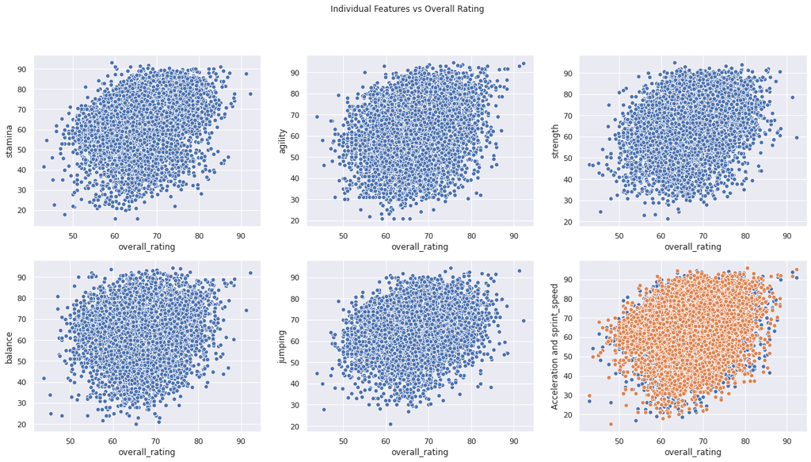

```python
fig, ax = plt.subplots(2, 3, figsize=(20, 10))
sns.scatterplot(x="overall_rating", y="stamina", data=players_data, ax=ax[0][0])
sns.scatterplot(x="overall_rating", y="agility", data=players_data, ax=ax[0][1])
sns.scatterplot(x="overall_rating", y="strength", data=players_data, ax=ax[0][2])
sns.scatterplot(x="overall_rating", y="balance", data=players_data, ax=ax[1][0])
sns.scatterplot(x="overall_rating", y="jumping", data=players_data, ax=ax[1][1])
sns.scatterplot(x="overall_rating", y="sprint_speed", data=players_data, ax=ax[1][2])
sns.scatterplot(x="overall_rating", y="acceleration", data=players_data, ax=ax[1][2])
ax[1][2].set_ylabel('Acceleration and sprint_speed')
# The acceleration and sprint_speed are combined into one graph to avoid an additional row.
fig.suptitle("Individual Features vs Overall Rating")
```

#### Plot a scatterplot combining all the attributes to show that they're evenly spread.

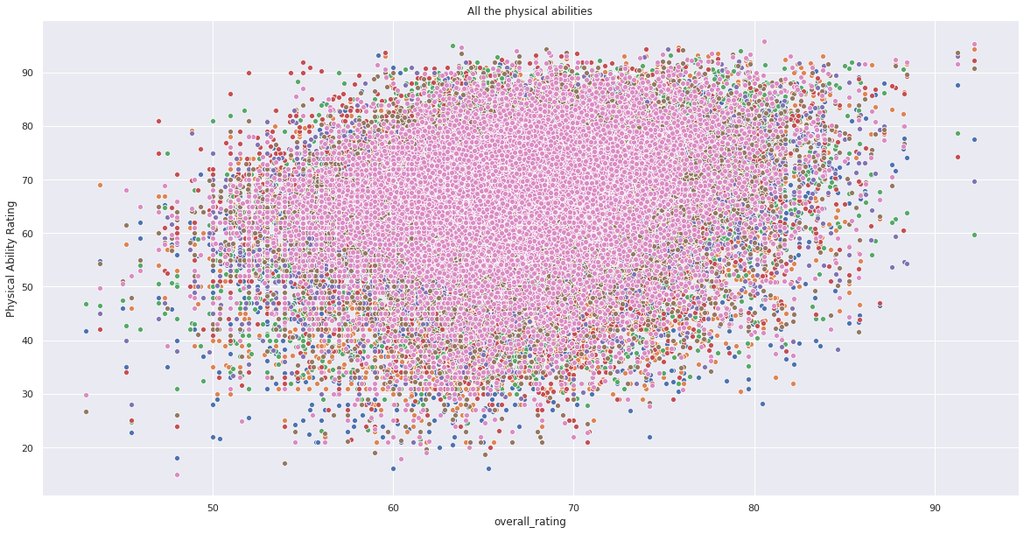

```python
fig, ax = plt.subplots(1, 1, figsize=(20, 10))
sns.scatterplot(x="overall_rating", y="stamina", data=players_data, ax=ax)
sns.scatterplot(x="overall_rating", y="agility", data=players_data, ax=ax)
sns.scatterplot(x="overall_rating", y="strength", data=players_data, ax=ax)
sns.scatterplot(x="overall_rating", y="balance", data=players_data, ax=ax)
sns.scatterplot(x="overall_rating", y="jumping", data=players_data, ax=ax)
sns.scatterplot(x="overall_rating", y="sprint_speed", data=players_data, ax=ax)
sns.scatterplot(x="overall_rating", y="acceleration", data=players_data, ax=ax)
ax.set_ylabel('Physical Ability Rating')
ax.set_title("All the physical abilities")
```

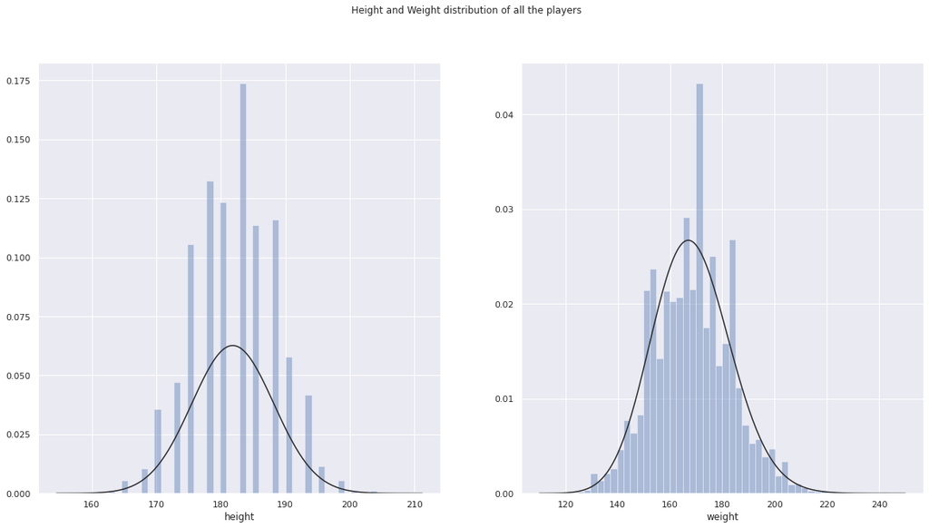

```python
fig, ax = plt.subplots(1, 2, figsize=(20, 10), frameon=False)
height = players_data['height']
weight = players_data['weight']
sns.distplot(height,kde=False, norm_hist=True, fit=stats.gamma, ax=ax[0])
sns.distplot(weight,kde=False, norm_hist=True, fit=stats.gamma, ax=ax[1])
height_std = round(players_data.describe().loc['std']['height'], 3)
weight_std = round(players_data.describe().loc['std']['weight'], 3)
fig.suptitle("Height and Weight distribution of all the players")
```

**These histograms prove that the heights and weights of all the players are evenly distributed.**  
**Standard deviation of height = 6.369 and weight = 14.99**  
**Also, the mean difference in height of players ranked above 80 and below 80 = 0.39. The same statistic for weight = 3.6**  
**Hence they're not deciding factors for judging a players ability and ranking.**

```python
drop_columns = ['stamina', 'agility', 'strength', 'balance', 'jumping', 'sprint_speed', 'acceleration', 'height', 'weight']
above80.drop(drop_columns, inplace=True)
below80.drop(drop_columns, inplace=True)
```

### So, what attributes decide a players ranking and abilities?

```python
above80 - below80
# This will give the difference in points for the attributes not removed in the previous step.
```

```
crossing              11.343660
finishing             14.556517
heading_accuracy       8.733812
short_passing         13.235272
volleys               17.755272
dribbling             12.351365
curve                 15.261815
free_kick_accuracy    14.924414
long_passing          13.150847
ball_control          13.560050
reactions             16.418959
shot_power            12.453266
long_shots            14.181629
aggression             7.154697
interceptions          9.024982
positioning           15.924623
vision                16.698739
penalties             17.146775
marking               -1.094549
standing_tackle        1.306627
sliding_tackle         1.040479
gk_diving              3.046729
gk_handling            3.528371
gk_kicking             7.890525
gk_positioning         3.623460
gk_reflexes            3.762144
Name: mean, dtype: float64
```

### Limitations

**The player_attributes table has been aggregated to give an average player statistic, as a result of which, we don't know how a players' ranking has changed ( increased or decreased ) over time.**  
**Inclusion of the aforementioned statistic would add more weightage to our observations, enabling us to understand the rise journey of a player in a better way.**